# CH2_Practice

Ben Jones

4 February 2019

## R Markdown

*2E1:* (2) & (4)

*2E2:* (3)

*2E3:* (1), by definition. Also (4), by Bayes theorem

*2E4:* What de finetti meant was likely that probability is simply a metric for expressing uncertainty regarding an outcome given the available information, and that this probability can change in light of new information. With regard to the statement “the probability of water is 0.7”, what we are saying is that given our observations with the globe tossing exercise, alongside any prior information we have, our best guess of the proportion of the earth’s surface covered in water is 0.7, although if we were to obtain more information this estimate could change.

*2M1:* i)

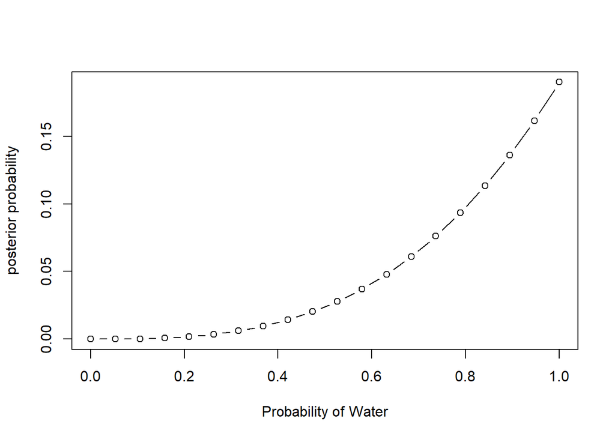

```r
p_grid = seq(0,1,length.out = 20)
prior = rep(1,20)
likelihood = dbinom(3,size = 3, prob = p_grid)
unstd.posterior = likelihood * prior
posterior = unstd.posterior/sum(unstd.posterior)
plot(p_grid, posterior, type = "b", xlab = "Probability of Water", ylab = "posterior probability")
```

ii)

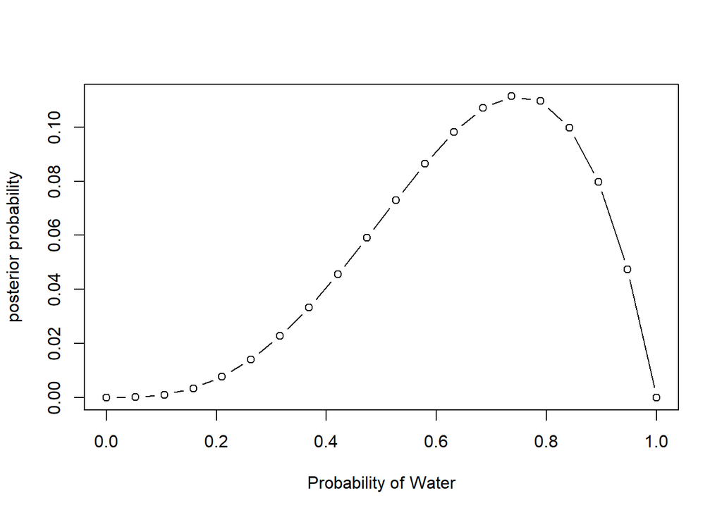

```r
p_grid2 = seq(0,1,length.out = 20)
prior2 = rep(1,20)
likelihood2 = dbinom(3,size = 4, prob = p_grid)
unstd.posterior2 = likelihood2 * prior2
posterior2 = unstd.posterior2/sum(unstd.posterior2)
plot(p_grid2, posterior2, type = "b", xlab = "Probability of Water", ylab = "posterior probability")
```

iii)

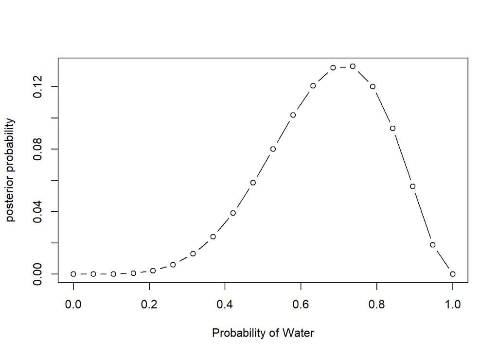

```r
p_grid3 = seq(0,1,length.out = 20)
prior3 = rep(1,20)
likelihood3 = dbinom(5,size = 7, prob = p_grid)
unstd.posterior3 = likelihood3 * prior3
posterior3 = unstd.posterior3/sum(unstd.posterior3)
plot(p_grid3, posterior3, type = "b", xlab = "Probability of Water", ylab = "posterior probability")
```

*2M2:* i)

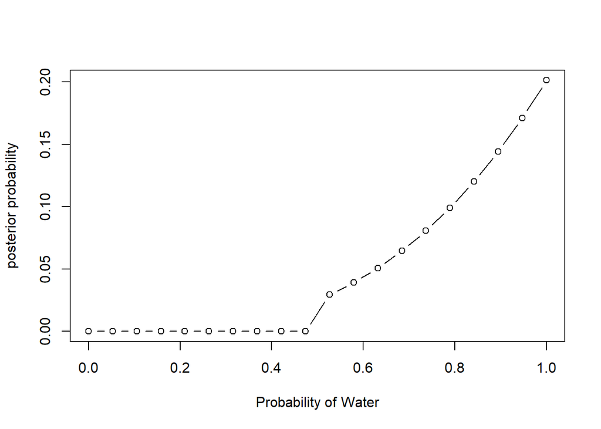

```r
p_grid4 = seq(0,1,length.out = 20)
prior4 = ifelse(p_grid4< 0.5,0,1)
likelihood4 = dbinom(3,size = 3, prob = p_grid)
unstd.posterior4 = likelihood4 * prior4
posterior4 = unstd.posterior4/sum(unstd.posterior4)
plot(p_grid4, posterior4, type = "b", xlab = "Probability of Water", ylab = "posterior probability")
```

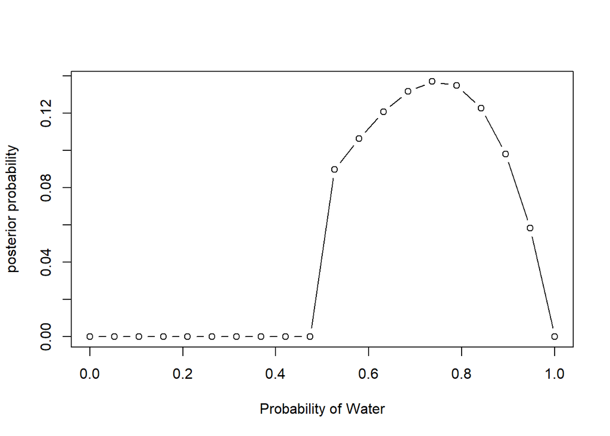

```r
p_grid5 = seq(0,1,length.out = 20)
prior5 = ifelse(p_grid4< 0.5,0,1)
likelihood5 = dbinom(3,size = 4, prob = p_grid)
unstd.posterior5 = likelihood5 * prior5
posterior5 = unstd.posterior5/sum(unstd.posterior5)
plot(p_grid5, posterior5, type = "b", xlab = "Probability of Water", ylab = "posterior probability")
```

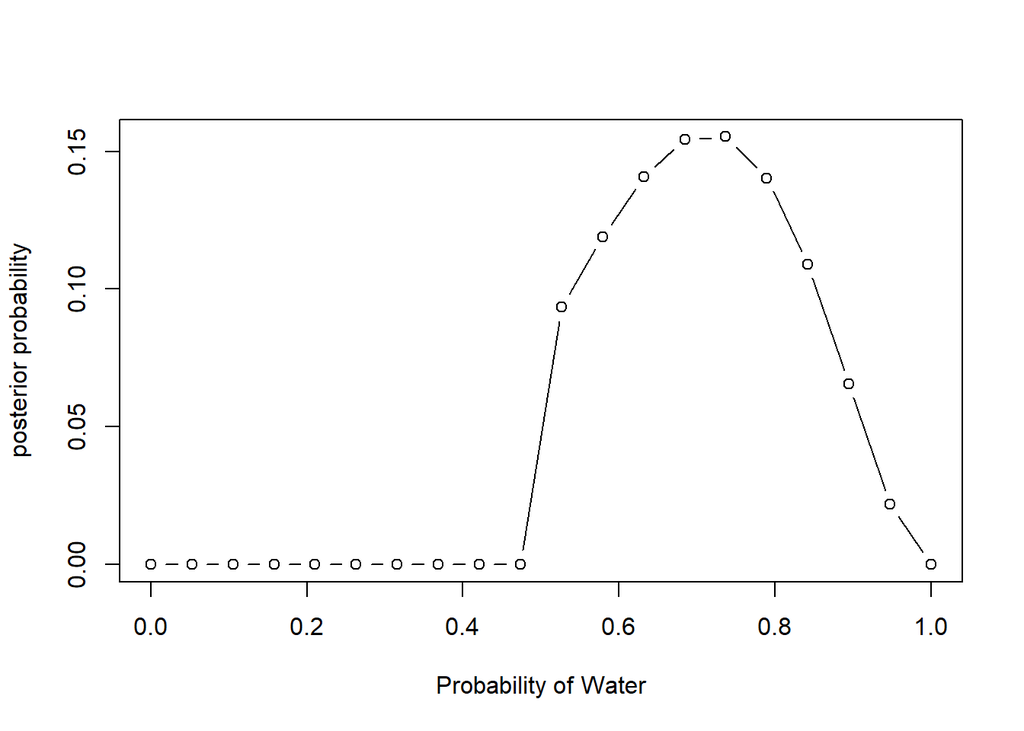

```r
p_grid6 = seq(0,1,length.out = 20)
prior6 = ifelse(p_grid4< 0.5,0,1)
likelihood6 = dbinom(5,size = 7, prob = p_grid)
unstd.posterior6 = likelihood6 * prior6
posterior6 = unstd.posterior6/sum(unstd.posterior6)
plot(p_grid6, posterior6, type = "b", xlab = "Probability of Water", ylab = "posterior probability")
```

*2M6:* There are now 12 ways to pull cards from the deck, of which four will show a black on the first side. Of these, two will also show a black on the second side, the probability that the card is black on both sides is $\frac{2}{4} = 0.5$

*2M7:* After pulling a black sided card first, there are 8 ways to then pull a second card, six of which arw white and two are black. All six of the white scenarios can result in a black on the second side of the first card, and both black scenarios results in a white on the second side of the first card. Therefore the probability is $\frac{6}{8} = 0.75$

*2H1:* We first must calculate the posterior of having twins at the first stage, which can then be used as the prior for the second stage

```r
likelihood <- c(0.1,0.2)
prior <- c(1,1)
unstd.posterior = likelihood * prior
posterior = unstd.posterior/sum(unstd.posterior)

#result
sum(posterior * likelihood)
```

```
## [1] 0.1666667
```

*2H2:* By Bayes’ theorem,
$$P(A|Twin) = \frac{P(Twin|A)P(A)}{P(Twin)} = \frac{0.1 \times 0.5}{0.15} = 0.33$$

*2H3:*

```r
likelihood <- c(0.1,0.2)
prior <- c(1,1)
unstd.posterior = likelihood * prior
posterior = unstd.posterior/sum(unstd.posterior)

#result
likelihood2 <- c(0.9,0.8)
unstd.posterior2 <- posterior * likelihood2
posterior2 <- unstd.posterior2/sum(unstd.posterior2)
posterior2[1]
```

```
## [1] 0.36
```

*2H4:* p1

```r
likelihood <- c(0.8,1-0.65)
prior = c(1,1)
unstd.posterior <- likelihood * prior
posterior <- unstd.posterior/sum(unstd.posterior)
posterior[1]
```

```
## [1] 0.6956522
```

p2 We need to calculate
$$\begin{align*}
P(A|Test = A, twins1, single2) &= \frac{P(test = A|Species = A) \times P(twins1|Species = A) \times P(single2|Species = A * P(Species = A))}{P(test = A, twins1, single2)} \\
P(test = A, twins1, single2) &= P(test = A|Species = A) * P(twins1 | species = A) * P(single2 | species = A) * P(Species = A)
\\&+ P(test = A|Species = B) * P(twins1 | species = B) * P(single2 | species = B) * P(Species = B) \\
&\iff \frac{0.8 \times 0.1 \times 0.9 \times 0.5}{0.8 \times 0.1 \times 0.9 \times 0.5 + 0.35 \times 0.2 \times 0.8 \times 0.5}
\end{align*}$$

```r
(0.8*0.1*0.9*0.5)/(0.8*0.1*0.9*0.5 + 0.35 * 0.2 * 0.8 * 0.5)
```

```
## [1] 0.5625
```